# MTH6139 Time Series

Nur Adlina Nabihah Adnan

Spring Term 2026

# Introduction

## What Are We Trying to Do?

This project investigates how much interest people in the **United Kingdom** have shown in **Malaysia** over the past two decades, as measured by Google search activity. We then use **Meta’s Prophet** forecasting system to predict how that interest might evolve over the next three years.

Why does this matter? Search interest is a useful proxy for **tourism intent**. When someone in the UK types “Malaysia” into Google, they might be researching a holiday, reading about a news event, or planning to visit friends and family. By modelling the trend and seasonal patterns in this data, we can gain insight into when Malaysia attracts the most attention for UK residents and whether that interest is growing or declining over time.

The data comes from **Google Trends**, which measures search interest on a relative scale from 0 to 100. A value of 100 represents the month with the highest search volume in the dataset; all other months are expressed as a proportion of that peak. This means we are not working with raw search counts but we are working with a **relative popularity index**.

## Installation

Prophet can be installed from CRAN or from Meta’s GitHub. These commands are shown for reference and should be run once in the R console, not inside this document:

```r
# Standard CRAN install
install.packages("prophet")

# Latest release from GitHub (recommended by Meta)
install.packages("remotes")
remotes::install_github("facebook/prophet@*release", subdir = "R")
```

For this project the CRAN version was used.

Here we are loading all libraries required for this file:

```r
library(prophet)  # Meta's Prophet forecasting system
library(ggplot2)  #Visualisation
library(lubridate) # Working with dates
```

# The Data

## Source: Google Trends

The data was downloaded from trends.google.com with the following settings:

- **Search term:** Malaysia
- **Geography:** United Kingdom
- **Time range:** January 2004 to present
- **Search type:** Web Search

When a date range spanning more than five years is selected, Google Trends automatically aggregates the data to **monthly** resolution. The result is a single column of values from 0 to 100, where **100 = the month with the highest search interest** in the entire period. Every other month is scaled relative to that peak.

## Loading and Cleaning

The CSV file has two columns which are `Time` and `Malaysia`. We load it, rename the columns to the names Prophet requires (`ds` for dates, `y` for values), and convert the date column to a proper R `Date` object.

```r
Malaysia <- read.csv("data/MalaysiaGoogleSearchinUK.csv")
```

```r
# Rename to Prophet-required names
colnames(Malaysia) <- c("ds", "y")

# Parse dates explicitly
Malaysia$ds <- as.Date(Malaysia$ds, format = "%Y-%m-%d")

# Ensure y is numeric
Malaysia$y <- as.numeric(Malaysia$y)

# Drop any incomplete rows
MalaysiaData <- Malaysia[complete.cases(Malaysia), ]
```

We have 267 monthly observations spanning over two decades. The average search index across the entire period is 12.4 out of 100. The peak month was March 2014 — almost certainly reflecting the intense global media coverage of the **MH370 disappearance**. The lowest recorded month was November 2020, during the depths of the **COVID-19 pandemic** when international travel had effectively stopped.

# Exploratory Analysis

Before fitting any model, we should spend time understanding the data visually and numerically. A good forecast starts with a good understanding of the series.

## The Full Picture (2004–2026)

[figure not shown]

```r
ggplot(MalaysiaData, aes(x = ds, y = y)) +
 geom_line(colour = "blue", linewidth = 0.6) +
 geom_point(size = 0.8, colour = "blue", alpha = 0.4) +
 # Annotate the two most notable events
 annotate("rect",xmin = as.Date("2014-03-01"), xmax = as.Date("2014-12-01"),
          ymin = -Inf, ymax = Inf,
          fill = "red", alpha = 0.1) +
 annotate("text", x = as.Date("2014-07-01"), y = 95,
          label = "MH370\nMar 2014", colour = "red", size = 3.5, fontface = "bold") +
 annotate("rect",
          xmin = as.Date("2020-03-01"), xmax = as.Date("2021-07-01"),
          ymin = -Inf, ymax = Inf,
          fill = "orange", alpha = 0.1) +
 annotate("text", x = as.Date("2020-11-01"), y = 95,
          label = "COVID-19\n2020–21", colour = "orange", size = 3.5, fontface = "bold") +
 labs(
     title = "UK Google Search Interest for \"Malaysia\", 2004–2026",
     subtitle = "Monthly relative index (0 = lowest, 100 = peak month) | Source: Google Trends",
     x = NULL,
     y = "Search Interest Index"
     ) +
theme_minimal(base_size = 13)
```

Two events stand out immediately:

1. **March 2014 — MH370:** Malaysia Airlines flight MH370 disappeared on 8 March 2014. The search index jumped dramatically as the story dominated global news for months. This is an **externally-driven spike** with no tourism meaning which reflects news interest, not travel intent.
2. **2020–2021 — COVID-19:** International travel restrictions caused UK search interest in Malaysia to fall to its lowest recorded levels. This is an **externally-driven trough** that temporarily suppressed what would otherwise have been normal seasonal search patterns.

Both of these are anomalies that could distort a forecasting model if left untreated.

# Prophet Forecasting

## Preparing the Model

Now that we understand the data, we are ready to fit a Prophet model. We use the cleaned `MalaysiaData` dataframe with the `ds` and `y` columns.

```r
ProphetModel <- prophet(MalaysiaData)
```

## Forecasting Three Years Ahead

We ask Prophet to generate forecasts for the next 36 months beyond the end of our data. The `make_future_dataframe()` function creates a dataframe of future dates, and `predict()` fills in the forecasted values along with uncertainty bounds.

```r
FutureDates <- make_future_dataframe(ProphetModel, periods = 36, freq = "month")
ProphetForecast <- predict(ProphetModel, FutureDates)

# Preview the future forecast rows
head(ProphetForecast[,c("ds", "yhat", "yhat_lower", "yhat_upper")], 5)
```

```
##           ds     yhat yhat_lower yhat_upper
## 1 2004-01-01 16.75108   9.786388   23.93109
## 2 2004-02-01 15.91653   8.626517   23.75538
## 3 2004-03-01 20.29124  12.882100   27.56452
## 4 2004-04-01 16.80601   9.995324   24.50964
## 5 2004-05-01 16.46098   9.270553   24.14699
```

```r
tail(ProphetForecast[,c("ds", "yhat", "yhat_lower", "yhat_upper")], 5)
```

```
##             ds     yhat yhat_lower yhat_upper
## 299 2028-11-01 10.49468   3.092850   17.84298
## 300 2028-12-01 11.21132   3.863257   18.56182
## 301 2029-01-01 12.33941   4.973453   19.59357
## 302 2029-02-01 11.71979   4.316962   19.34416
## 303 2029-03-01 16.28249   8.493833   23.60814
```

## The Forecast Plot

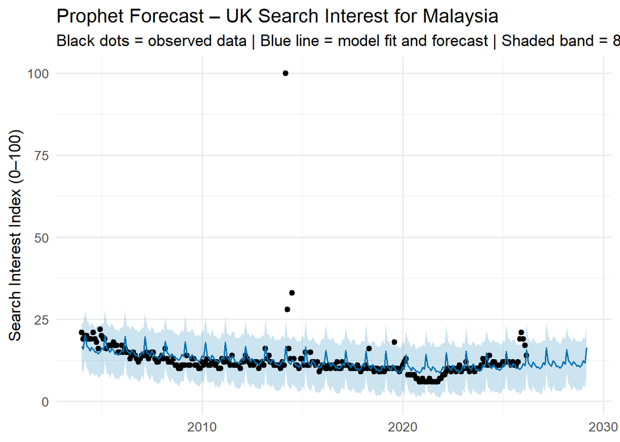

```r
plot(ProphetModel, ProphetForecast) +
 labs(
 title = "Prophet Forecast – UK Search Interest for Malaysia",
 subtitle = "Black dots = observed data | Blue line = model fit and forecast | Shaded band = 80% uncertainty interval",
 x = NULL,
 y = "Search Interest Index (0–100)"
 ) +
 theme_minimal(base_size = 13)
```

- The model fits the historical data reasonably well, capturing both the general trend and the recurring seasonal peaks.
- The MH370 spike in 2014 is partially absorbed into the trend, which may cause a slight overestimate in the near-term forecast if that spike inflated the perceived level of the series.
- The COVID-19 trough is also visible — Prophet treats this as a genuine change point rather than a temporary anomaly, which means the post-COVID recovery is being modelled as a new trend phase.
- The forecast for 2026–2028 shows **modest continued interest**, with the seasonal pattern persisting.

## Decomposing the Forecast: Trend and Seasonality

We can decompose the forecast into its constituent components. This lets us separately examine the **long-run trend** and the **seasonal pattern**, rather than having them mixed together in a single line.

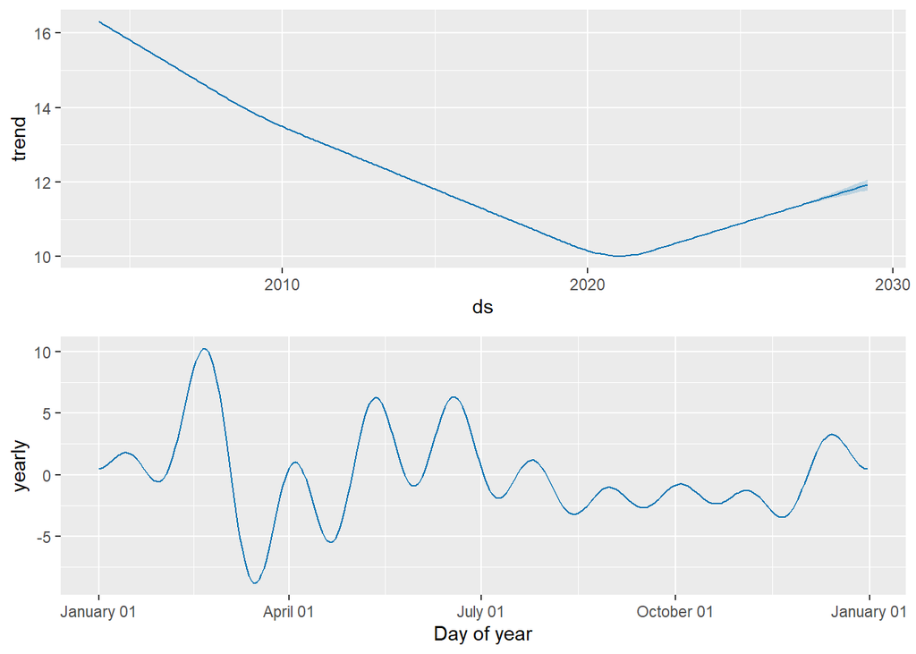

```r
prophet_plot_components(ProphetModel, ProphetForecast)
```

**Yearly seasonality :** This graph shows the average within-year pattern, expressed as the contribution to the index from seasonality alone. Positive values mean that month tends to be above the trend; negative values mean below it. A peak in July or August would confirm that UK summer holidays are the primary driver of seasonal search interest in Malaysia.

# Discussion and Conclusions